# Introduction to the NicheMapR ectotherm model

Michael Kearney

2018-05-09

This vignette provides a detailed tutorial of the Niche Mapper ectotherm model as implemented in the package *NicheMapR*. It only considers the base heat and (partial) water budget model. For details on the implementation of the Dynamic Energy Budget model (for simulating growth, development and reproduction as well as full water budgets), see the *DEB-model-tutorial* vignette (on the to do list!).

## Overview

### Basic operation: modelling heat and activity budgets for the average day of each month

As with the microclimate model tutorial, this first example involves the most basic case of running the model to produce 12 days of output, one for each month of the year. Try running the model with the default inputs for a location of your choice, e.g.:

```r
library(NicheMapR)
```

```r
library(NicheMapR)
micro<-micro_global(loc = "Townsville Queensland", runmoist = 1)
```

```
## extracting climate data
```

```
## running microclimate model for 12 days by 1 years at site Townsville Queensland
```

```
## runtime 0.520000000000003 seconds
```

```r
longlat <- c(micro$longlat[1], micro$longlat[2]) # save the longitude and latitude and pass directly below
ecto<-ectotherm()
```

```
## running ectotherm model ...
```

```
## runtime 0.0499999999999972 seconds
```

The results are stored as a list in the variable *ecto*. The main ones to focus on for now are

- **environ** The body temperature, activity and envionments experienced by the animal
- **enbal** The components of the computed heat budget
- **masbal** The components of the computed mass budget

The output table **environ** look like this (first 15 columns):

| DOY | YEAR | DAY | TIME | TC | SHADE | SOLAR | DEP | ACT | TA | TSUB | TSKY | VEL | RELHUM | ZEN |
| --- | --- | --- | --- | --- | --- | --- | --- | --- | --- | --- | --- | --- | --- | --- |
| 15 | 1 | 1 | 1 | 28.31 | 0 | 0.00 | -2.5 | 0 | 28.15 | 28.15 | 28.15 | 0.01 | 100.00 | 90.00 |
| 15 | 1 | 1 | 2 | 27.05 | 0 | 0.00 | -2.5 | 0 | 26.91 | 26.91 | 26.91 | 0.01 | 99.99 | 90.00 |
| 15 | 1 | 1 | 3 | 26.25 | 0 | 0.00 | -2.5 | 0 | 26.11 | 26.11 | 26.11 | 0.01 | 99.99 | 90.00 |
| 15 | 1 | 1 | 4 | 25.78 | 0 | 0.00 | -2.5 | 0 | 25.65 | 25.65 | 25.65 | 0.01 | 99.99 | 90.00 |
| 15 | 1 | 1 | 5 | 25.54 | 0 | 0.00 | -2.5 | 0 | 25.42 | 25.42 | 25.42 | 0.01 | 99.99 | 90.00 |
| 15 | 1 | 1 | 6 | 25.45 | 0 | 0.00 | -2.5 | 0 | 25.33 | 25.33 | 25.33 | 0.01 | 99.99 | 90.00 |
| 15 | 1 | 1 | 7 | 29.55 | 0 | 63.69 | 0.0 | 2 | 23.99 | 23.85 | 16.48 | 0.12 | 82.84 | 83.14 |
| 15 | 1 | 1 | 8 | 29.98 | 21 | 141.03 | 0.0 | 2 | 25.72 | 26.34 | 17.98 | 0.19 | 74.68 | 69.69 |
| 15 | 1 | 1 | 9 | 29.85 | 39 | 144.09 | 0.0 | 2 | 27.28 | 27.93 | 19.84 | 0.27 | 68.53 | 55.98 |
| 15 | 1 | 1 | 10 | 29.79 | 51 | 129.47 | 0.0 | 2 | 28.54 | 28.13 | 21.75 | 0.34 | 64.77 | 42.13 |
| 15 | 1 | 1 | 11 | 29.96 | 60 | 104.20 | 0.0 | 2 | 29.73 | 28.12 | 23.57 | 0.41 | 61.30 | 28.17 |
| 15 | 1 | 1 | 12 | 29.87 | 66 | 83.98 | 0.0 | 2 | 30.65 | 27.12 | 24.91 | 0.49 | 53.11 | 14.20 |

and includes the following variables:

1. DOY - day of year
2. YEAR - year of simulation
3. DAY - day of simulation
4. TIME - time of day (hours)
5. TC - body temperature (°C)
6. SHADE - shade selected (%)
7. SOLAR - solar radiation (W/m2) at animal location
8. DEP - depth below ground (cm)
9. ACT - activity state (0=inactive, 1=basking, 2=foraging)
10. TA - air temperature (°C) at animal location
11. VEL - wind speed (m/s) at animal location
12. RELHUM - relative humidity (%) at animal location
13. ZEN - zenith angle of sun (degrees, where 90° = below the horizon)
14. CONDEP - depth of water body (cm) (may not be simulated or supplied)
15. WATERTEMP - temperature of water body (°C) (may not be simulated or supplied)
16. DAYLENGTH - day length (hours)
17. WINGANGLE - wing angle (degrees) for butterfly model
18. WINGTEMP - wing temperature (°C) for butterfly model
19. FLYING - flying state (1=flying, 0=not flying) for butterfly model
20. FLYTIME - flying time (hours) for butterfly model

The model has considered, for each hour of the day, where the organism could be conditional on the behavioural options set. The default simulation is for the Eastern Water Skink, *Eulamprus quoyii*, which is diurnal (*dayact* = 1, *nocturn* = 0, *crepus* = 0). So, for the nighttime and twilight hours, the animal is assumed to be underground (*burrow* = 1). The algorithm choosing the depth to put the animal starts at the shallowest depth allowed and moves deeper only if it would go below the stated critical thermal minimum *ctmin* (6 °C by default) or if it would be half way between the maximum voluntary foraging temperature *VTMAX* (34 °C by default) and the critical thermal maximum *ctmax* (40 °C by default). Note how the wind speed is set to an arbitrarily low value when then animal is sheltering under ground, and the air, substrate and ‘sky’ temperatures are set to be equal to the soil temperature at the chosen depth.

The output table **enbal** looks like this:

| DOY | YEAR | DAY | TIME | QSOL | QIRIN | QMET | QEVAP | QIROUT | QCONV | QCOND | ENB | NTRY |
| --- | --- | --- | --- | --- | --- | --- | --- | --- | --- | --- | --- | --- |
| 15 | 1 | 1 | 1 | 0.00 | 4.70 | 0.02 | 0.00 | 4.71 | 0.01 | 0.00 | 0 | 1 |
| 15 | 1 | 1 | 2 | 0.00 | 4.63 | 0.01 | 0.00 | 4.63 | 0.01 | 0.00 | 0 | 1 |
| 15 | 1 | 1 | 3 | 0.00 | 4.58 | 0.01 | 0.00 | 4.58 | 0.01 | 0.00 | 0 | 1 |
| 15 | 1 | 1 | 4 | 0.00 | 4.55 | 0.01 | 0.00 | 4.56 | 0.01 | 0.00 | 0 | 1 |
| 15 | 1 | 1 | 5 | 0.00 | 4.54 | 0.01 | 0.00 | 4.54 | 0.01 | 0.00 | 0 | 1 |
| 15 | 1 | 1 | 6 | 0.00 | 4.53 | 0.01 | 0.00 | 4.54 | 0.01 | 0.00 | 0 | 1 |
| 15 | 1 | 1 | 7 | 2.21 | 4.23 | 0.02 | 0.01 | 4.79 | 0.82 | 0.84 | 0 | 1 |
| 15 | 1 | 1 | 8 | 1.74 | 4.35 | 0.02 | 0.01 | 4.82 | 0.75 | 0.53 | 0 | 8 |
| 15 | 1 | 1 | 9 | 1.14 | 4.45 | 0.02 | 0.01 | 4.81 | 0.52 | 0.28 | 0 | 14 |
| 15 | 1 | 1 | 10 | 0.80 | 4.51 | 0.02 | 0.01 | 4.81 | 0.27 | 0.24 | 0 | 18 |
| 15 | 1 | 1 | 11 | 0.55 | 4.56 | 0.02 | 0.01 | 4.82 | 0.04 | 0.26 | 0 | 21 |
| 15 | 1 | 1 | 12 | 0.41 | 4.57 | 0.02 | 0.01 | 4.81 | -0.22 | 0.40 | 0 | 23 |

It quantifies the different pathways of exchange in each hour of the simulation:

1. DOY - day of year
2. YEAR - year of simulation
3. DAY - day of simulation
4. TIME - time of day (hours)
5. TC - body temperature (°C)
6. QSOL - solar radiation absorbed (W)
7. QIRIN - infrared radiation absorbed (W)
8. QMET - metabolic heat production (W)
9. QEVAP - evaporative heat loss (W)
10. QIROUT - infrared radiation lost (W)
11. QCONV - heat lost by convection (W)
12. QCOND - heat lost by conduction (W)
13. ENB - energy balance (°C)
14. NTRY - iterations required for solution to heat balance equation

where the complete heat budget is

$ENB = QSOL + QIRIN + QMET - QEVAP - QIROUT - QCONV - QCOND$

Finally, the output table **masbal** looks like this:

| DOY | YEAR | DAY | TIME | O2_ml | CO2_ml | NWASTE_g | H2OFree_g | H2OMet_g | DryFood_g |
| --- | --- | --- | --- | --- | --- | --- | --- | --- | --- |
| 15 | 1 | 1 | 1 | 2.959909 | 0 | 0 | 0 | 0 | 0 |
| 15 | 1 | 1 | 2 | 2.651160 | 0 | 0 | 0 | 0 | 0 |
| 15 | 1 | 1 | 3 | 2.471271 | 0 | 0 | 0 | 0 | 0 |
| 15 | 1 | 1 | 4 | 2.372704 | 0 | 0 | 0 | 0 | 0 |
| 15 | 1 | 1 | 5 | 2.323775 | 0 | 0 | 0 | 0 | 0 |
| 15 | 1 | 1 | 6 | 2.304648 | 0 | 0 | 0 | 0 | 0 |
| 15 | 1 | 1 | 7 | 3.300526 | 0 | 0 | 0 | 0 | 0 |
| 15 | 1 | 1 | 8 | 3.426471 | 0 | 0 | 0 | 0 | 0 |
| 15 | 1 | 1 | 9 | 3.388503 | 0 | 0 | 0 | 0 | 0 |
| 15 | 1 | 1 | 10 | 3.371055 | 0 | 0 | 0 | 0 | 0 |
| 15 | 1 | 1 | 11 | 3.419202 | 0 | 0 | 0 | 0 | 0 |
| 15 | 1 | 1 | 12 | 3.394183 | 0 | 0 | 0 | 0 | 0 |

| WetFood_g | DryFaeces_g | WetFaeces_G | Urine_g | H2OResp_g | H2OCut_g | H2OEye_g | H2OBal_g | H2OCumBal_g |
| --- | --- | --- | --- | --- | --- | --- | --- | --- |
| 0 | 0 | 0 | 0 | -0.0000697 | 0.0000290 | 0.0000000 | 0 | 0 |
| 0 | 0 | 0 | 0 | -0.0000595 | 0.0000244 | 0.0000000 | 0 | 0 |
| 0 | 0 | 0 | 0 | -0.0000536 | 0.0000218 | 0.0000000 | 0 | 0 |
| 0 | 0 | 0 | 0 | -0.0000505 | 0.0000204 | 0.0000000 | 0 | 0 |
| 0 | 0 | 0 | 0 | -0.0000489 | 0.0000198 | 0.0000000 | 0 | 0 |
| 0 | 0 | 0 | 0 | -0.0000483 | 0.0000195 | 0.0000000 | 0 | 0 |
| 0 | 0 | 0 | 0 | 0.0010109 | 0.0057532 | 0.0019184 | 0 | 0 |
| 0 | 0 | 0 | 0 | 0.0011205 | 0.0072854 | 0.0024293 | 0 | 0 |
| 0 | 0 | 0 | 0 | 0.0010769 | 0.0080988 | 0.0027005 | 0 | 0 |
| 0 | 0 | 0 | 0 | 0.0010328 | 0.0085326 | 0.0028452 | 0 | 0 |
| 0 | 0 | 0 | 0 | 0.0010510 | 0.0088978 | 0.0029669 | 0 | 0 |
| 0 | 0 | 0 | 0 | 0.0011799 | 0.0114579 | 0.0038206 | 0 | 0 |

1. DOY - day of year
2. YEAR - year of simulation
3. DAY - day of simulation
4. TIME - time of day (hours)
5. O2_ml - oxygen consumption rate (ml/h)
6. CO2_ml - carbon dioxide production rate (ml/h)
7. NWASTE_g - nitrogenous waste production (g/h)
8. H2OFree_g - water from food (g/h)
9. H2OMet_g - metabolic water production (g/h)
10. DryFood_g - dry food intake (g/h)
11. WetFood_g - wet foood intake (g/h)
12. DryFaeces_g - dry faeces production (g/h)
13. WetFaeces_G - wet faeces production (g/h)
14. Urine_g - urine production (g/h)
15. H2OResp_g - respiratory water loss (g/h)
16. H2OCut_g - cutaneous water loss (g/h)
17. H2OEye_g - ocular water loss (g/h)
18. H2OBal_g - instantaneous water balance (g/h)
19. H2OCumBal_g - cumulative water balance (g)

Most of these columns are zero because we are not running the on-board mass budget model (the Dynamic Energy Budget model, i.e. *DEB* = 0 by default). We are instead obtaining the oxygen consumption rate (ml/h) by an allometric function based on Eq. 2 from Andrews & Pough 1985,

$V_{O_2} = M_1 M^{ M_2} 10^{M_3 T_b}$

where $M$ is the mass in grams, $T_b$ is the body temperature, and $M_1$, $M_2$ and $M_3$ are constants which can be user-defined. From this and the oxygen extraction efficiency *extref* and difference in temperature between expired and inspired air *DETLAIR* (0.1 °C by default), the respiratory water loss *H2OResp_g* can be computed. From the percentage of the skin that is ‘wet’ *skinwet* one can estimate the cutaneous water loss *H2O_cut*. The *skinwet* parameter represents the % surface area that would act as free water surface if all the little pores letting water through the skin were collected together in one place. Finally, the parameter *aeyes* is the % of the total surface area taken up by the eyes when open, and is used to compute ocular water loss when the animal is active (a substantial part of the water loss!). If you are interested in the other quantities available in the **masbal** output, you will need to develop a DEB model for your species (see the [Dynamic Energy Budget lab](http://www.bio.vu.nl/thb/deb/deblab/), particularly the [Add-my-pet Portal](http://www.bio.vu.nl/thb/deb/deblab/add_my_pet/), for details, as well as the vignette (to do!) which explains the **debout** ouptut table).

## Plotting some output

Now let’s take a more detailed look at the results, by running the following code:

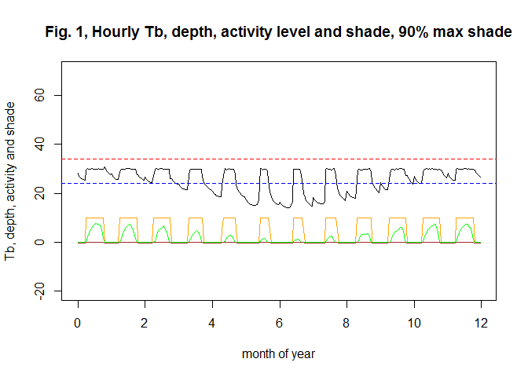

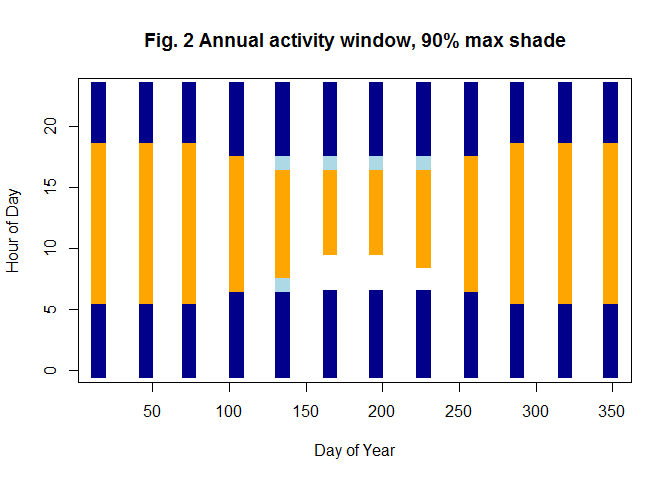

```r
# retrieve output
metout<-as.data.frame(micro$metout) # above ground microclimatic conditions, min shade
environ<-as.data.frame(ecto$environ) # activity, Tb and environment
enbal<-as.data.frame(ecto$enbal) # energy balance values
masbal<-as.data.frame(ecto$masbal) # mass balance value (note most missing if DEB
#model not running)

# append dates
days<-rep(seq(1,12),24)
days<-days[order(days)]
dates<-days+metout$TIME/60/24-1 # dates for hourly output
dates2<-seq(1,12,1) # dates for daily output
metout<-cbind(dates,metout)
environ<-cbind(dates,environ)
masbal<-cbind(dates,masbal)
enbal<-cbind(dates,enbal)

# Hourly Tb (black), activity (orange, 5=bask, 10=forage), depth (brown, m) and shade
# (green, %/10)
with(environ, plot(TC~dates,ylab="Tb, depth, activity and shade", xlab="month of year",
ylim=c(-20,70),type = "l", main =
    "Fig. 1, Hourly Tb, depth, activity level and shade, 90% max shade"))
with(environ, points(ACT*5~dates,type = "l",col="orange"))
with(environ, points(SHADE/10~dates,type = "l",col="green"))
with(environ, points(DEP/10~dates,type = "l",col="brown"))
abline(ecto$VTMAX,0,lty=2,col='red')
abline(ecto$VTMIN,0,lty=2,col='blue')

# seasonal activity plot (dark blue = night, light blue = basking, orange = foraging)
forage<-subset(environ,ACT==2)
bask<-subset(environ,ACT==1)
night<-subset(metout,ZEN==90)
day<-subset(metout,ZEN!=90)
with(night,plot(TIME/60~DOY,ylab="Hour of Day",xlab="Day of Year",pch=15,cex=2,col=
    'dark blue', main = "Fig. 2 Annual activity window, 90% max shade"))
# nighttime hours
with(forage,points((TIME-1)~DOY,pch=15,cex=2,col='orange')) # foraging Tbs
with(bask,points((TIME-1)~DOY,pch=15,cex=2,col='light blue')) # basking Tbs
```

In Fig. 1 you can see the daily cycles, for each month, of the body temperature (black), % shade selected (green, divided by 10 for plotting), activity level in orange (multiplied by 5 for plotting, so 5 = basking, 10 = active) and depth in brown (m). Also superimposed are the voluntary foraging thresholds *VTMIN* (blue dashed line) and *VTMAX* (red dashed line). Note how this lizard is active every day, but requires shade for this, and how body temperature jumps up on some evenings when it goes into its burrow (remember when inactive the body temperature may rise to a maximum of half way between *VTMAX* and *CTMAX* before the animal moves deeper into the burrow).

Explore what changing the thermal thresholds *CTMIN*, *TEMERGE*, *TBASK*, *VTMIN*, *VTMAX* and *CTMAX* does to these plots, as well as variation in available shade *maxshades* and burrow depths *mindepth* and *maxdepth*. Here is an example of the effect of reducing maximum shade in all months from 90% to 50%:

```r
ecto<-ectotherm(maxshades = rep(50,12))
```

```
## running ectotherm model ...
```

```
## runtime 0.109999999999999 seconds
```

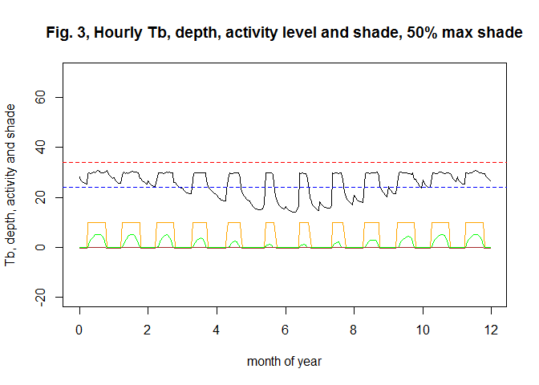

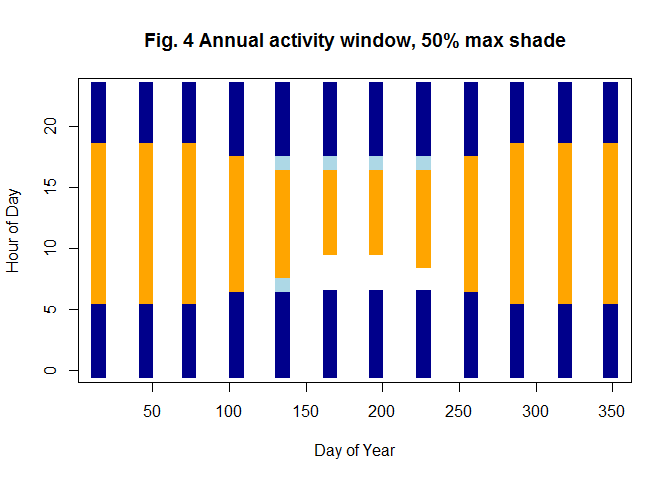

## Preview of the Dynamic Energy Budget model in action

The capacity to compute body temperature, metabolic rates, activity times and some aspects of the water budget allow many important inferences to be made about the ability of different types of animals to live in different climates and habitats. In some cases such processes may be limiting factors in the distribution. For example, Kearney and Porter (2004) found that activity time was likely to be a limiting factor for a nocturnal lizard in southern Australia. More often, these constraints act to limit the overall energy and water budget in a more subtle manner.

The preliminary computations made in this tutorial can provide the starting point for an energy budget analysis that could ultimately allow you to predict reproductive success and survival rates, key vital rates from which to infer distribution and abundance. One of the most powerful ways of achieving a full mass balance and life cycle trajectory is by using the Dynamic Energy Budget model (Kooijman, 2010), the ‘standard model’ of which is optionally implemented in the **ectotherm** model.

```r
# run the microclimate model daily for 5 years
timeinterval<-365
nyears<-6
micro<-micro_global(loc = longlat, timeinterval = timeinterval, nyears = nyears, runmoist = 1)
```

```
## extracting climate data
```

```
## running microclimate model for 365 days by 6 years at site long 146.8169483 lat -19.2589635
```

```
## runtime 62.82 seconds
```

```r
# run the ectotherm model with the DEB model turned on and in viviparous mode, simulating the
# Eastern Water Skink, Eulamprus quoyii
ecto<-ectotherm(DEB = 1, viviparous = 1)
```

```
## running ectotherm model ...
```

```
## runtime 4.72000000000001 seconds
```

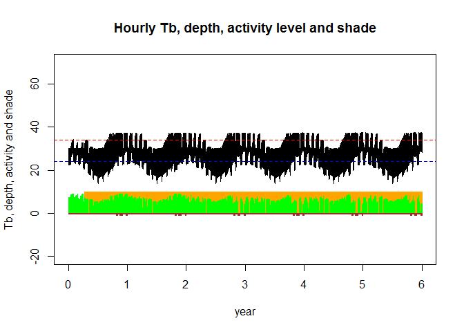

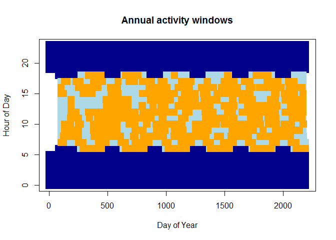

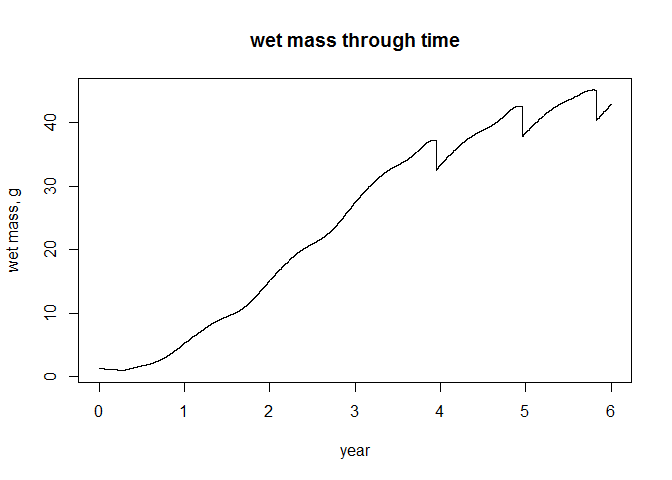

```r
metout<-as.data.frame(micro$metout) # above ground microclimatic conditions, min shade
environ<-as.data.frame(ecto$environ) # activity, Tb and environment
masbal<-as.data.frame(ecto$masbal) # activity, Tb and environment
debout<-as.data.frame(ecto$debout) # activity, Tb and environment

# append dates
days<-rep(seq(1,timeinterval*nyears),24)
days<-days[order(days)]
dates<-(days+metout$TIME/60/24-1)/365 # dates for hourly output
metout<-cbind(dates,metout)
environ<-cbind(dates,environ)
masbal<-cbind(dates,masbal)
debout<-cbind(dates,debout)

# Hourly Tb (black), activity (orange, 5=bask, 10=forage), depth (brown, m) and shade
# (green, %/10)
with(environ, plot(TC~dates,ylab="Tb, depth, activity and shade", xlab="year",
ylim=c(-20,70),type = "l", main = "Hourly Tb, depth, activity level and shade"))
with(environ, points(ACT*5~dates,type = "l",col="orange"))
with(environ, points(SHADE/10~dates,type = "l",col="green"))
with(environ, points(DEP/10~dates,type = "l",col="brown"))
abline(ecto$VTMAX,0,lty=2,col='red')
abline(ecto$VTMIN,0,lty=2,col='blue')

# seasonal activity plot (dark blue = night, light blue = basking, orange = foraging)
forage<-subset(environ,ACT==2)
bask<-subset(environ,ACT==1)
night<-subset(cbind(metout,debout$DAY),ZEN==90)
day<-subset(cbind(metout,debout$DAY),ZEN!=90)
colnames(night)[21]<-"DAY"
colnames(day)[21]<-"DAY"
with(night,plot(TIME/60~DAY,ylab="Hour of Day",xlab="Day of Year",pch=15,cex=2,col='dark blue',
  main = "Annual activity windows"))
with(bask,points((TIME-1)~DAY,pch=15,cex=2,col='light blue')) # basking Tbs
with(forage,points((TIME-1)~DAY,pch=15,cex=2,col='orange')) # foraging Tbs

with(debout, plot(WETMASS~dates,ylab="wet mass, g", xlab="year",
type = "l", main = "wet mass through time"))
```

## References

Andrews, R. M., and H. F. Pough. 1985. Metabolism of squamate reptiles: allometric and ecological relationships. Physiological Zoology 58:214-231.

Kearney, M., and W. P. Porter. 2004. Mapping the fundamental niche: physiology, climate, and the distribution of a nocturnal lizard. Ecology 85:3119-3131.

Kooijman, S. A. L. M. 2010. Dynamic Energy Budget Theory for Metabolic Organisation. Cambridge University Press, Great Britain.

Schwarzkopf, L., M. J. Caley, and M. R. Kearney. 2016. One lump or two? Explaining a major latitudinal transition in reproductive allocation in a viviparous lizard. Functional Ecology. DOI: 10.1111/1365-2435.12622